# Discovery and Data Prep of AirBnB listings in NY

Brandon Walker

October 8, 2019

## Introduction

My motivation for choosing the topic of economics and how it relates to Airbnb was to see how different Neighborhoods affected the price and rating of different listings.

## Identification of Data Set

First we need to load the tidyverse library, I suppress the messages and warnings so they wont be included in the knitted rmd file.

```r
suppressMessages(suppressWarnings(library(tidyverse)))
```

Now we have to load the Airbnb dataset that I have downloaded in the current working directory

```r
setwd("./")
airbnb <- read.csv("./AB_NYC_2019.csv")
```

## Description of Source

The Dataset can be found at: https://www.kaggle.com/dgomonov/new-york-city-airbnb-open-data

The Source has been taken from a public dataset that is part of Airbnb, and they have posted the data from the New York area.

This seems to be a trustworthy source, however there may be information left out. I am not sure if this is all the data from New York or if this is just what they have taken. This could be a limitation because I am not really sure how the data was gathered from Airbnb, and if some variables have been left out.

## Variable Documentation

First, lets look at the column names and how each variable has been stored.

```r
colnames(airbnb)
```

```
##  [1] "id"                             "name"
##  [3] "host_id"                        "host_name"
##  [5] "neighbourhood_group"            "neighbourhood"
##  [7] "latitude"                       "longitude"
##  [9] "room_type"                      "price"
## [11] "minimum_nights"                 "number_of_reviews"
## [13] "last_review"                    "reviews_per_month"
## [15] "calculated_host_listings_count" "availability_365"
```

```r
for(i in 1:16) {
  print(typeof(airbnb[1,i]))
}
```

```
## [1] "integer"
## [1] "integer"
## [1] "integer"
## [1] "integer"
## [1] "integer"
## [1] "integer"
## [1] "double"
## [1] "double"
## [1] "integer"
## [1] "integer"
## [1] "integer"
## [1] "integer"
## [1] "integer"
## [1] "double"
## [1] "integer"
## [1] "integer"
```

## Clean Data

Now firstly to clean the data, I am changing the values of each variable to what they should be. For example the character variables have been saved as integers.

```r
airbnb$name <- as.character(airbnb$name)
airbnb$host_name <- as.character(airbnb$host_name)
airbnb$neighbourhood <- as.character(airbnb$neighbourhood)
airbnb$neighbourhood_group <- as.character(airbnb$neighbourhood_group)
airbnb$room_type <- as.character(airbnb$room_type)
airbnb$last_review <- as.Date(airbnb$last_review)
```

Now I am going to change the categorical variables to be treated as factors.

```r
airbnb$neighbourhood_group <- as.factor(airbnb$neighbourhood_group)
airbnb$neighbourhood <- as.factor(airbnb$neighbourhood)
airbnb$room_type <- as.factor(airbnb$room_type)
```

Just to check and make sure it all worked

```r
for(i in 1:16) {
  print(typeof(airbnb[1,i]))
}
```

```
## [1] "integer"
## [1] "character"
## [1] "integer"
## [1] "character"
## [1] "integer"
## [1] "integer"
## [1] "double"
## [1] "double"
## [1] "integer"
## [1] "integer"
## [1] "integer"
## [1] "integer"
## [1] "double"
## [1] "double"
## [1] "integer"
## [1] "integer"
```

```r
head(levels(airbnb$neighbourhood))
```

```
## [1] "Allerton"      "Arden Heights" "Arrochar"      "Arverne"
## [5] "Astoria"       "Bath Beach"
```

```r
levels(airbnb$neighbourhood_group)
```

```
## [1] "Bronx"         "Brooklyn"      "Manhattan"     "Queens"
## [5] "Staten Island"
```

```r
levels(airbnb$room_type)
```

```
## [1] "Entire home/apt" "Private room"    "Shared room"
```

I am going to now split this one large table into two smaller tables. One table will be related to the host, and the other table will be related to the listing. Both tables will include the listing id so we can use that to link them.

```r
Hosts <- tibble(listing_id = airbnb$id, host_id = airbnb$host_id, host_name = airbnb$host_name, number_of_listings = airbnb$calculated_host_listings_count)

Listings <- tibble(listing_id = airbnb$id, name = airbnb$name, neighborhood = airbnb$neighbourhood, neighborhood_group = airbnb$neighbourhood_group, latitude = airbnb$latitude, longitude = airbnb$longitude, room_type = airbnb$room_type, price = airbnb$price, minimum_nights = airbnb$minimum_nights, number_of_reviews = airbnb$number_of_reviews, last_review = airbnb$last_review, reviews_per_month = airbnb$reviews_per_month, availability = airbnb$availability_365)

Listings <- Listings[order(Listings$listing_id),]
Hosts <- Hosts[order(Hosts$listing_id),]
```

The data is now clean.

## Visualization

Now since the data has been cleaned, we can start to visualize it using graphs and summaries.

I am going to graph how many hosts have a certain number of listings using a bar graph.

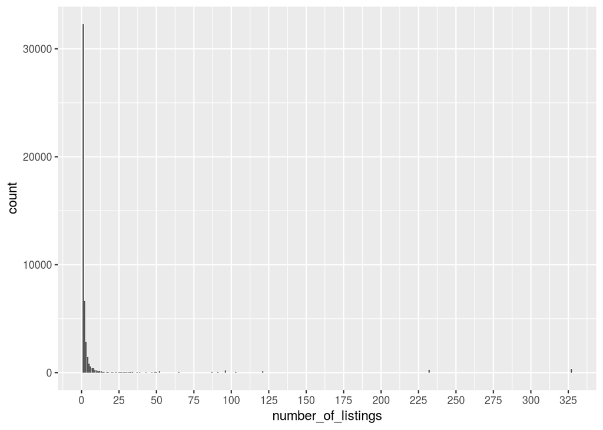

```r
ggplot(Hosts, aes(number_of_listings)) + geom_bar() + scale_x_continuous(breaks = seq(0, max(Hosts$number_of_listings), 25))
```

As we can see, the majority of hosts own around 1 to 25 listings. However there are some hosts that have a lot of listings, one at around 225, and another at around 325.

I am now going to plot how many listings are in each neighborhood group.

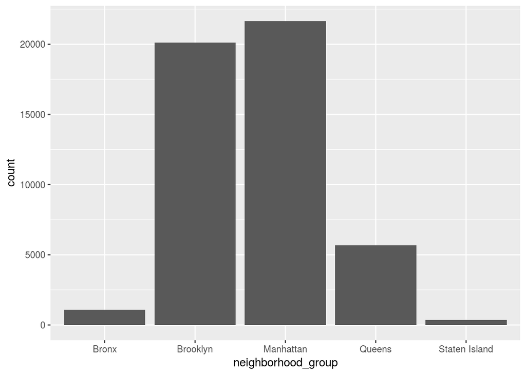

```r
ggplot(Listings, aes(neighborhood_group)) + geom_bar()
```

We can see that Brooklyn and Manhattan have the majority of the listings.

I am also going to check how many listings there are based on room type.

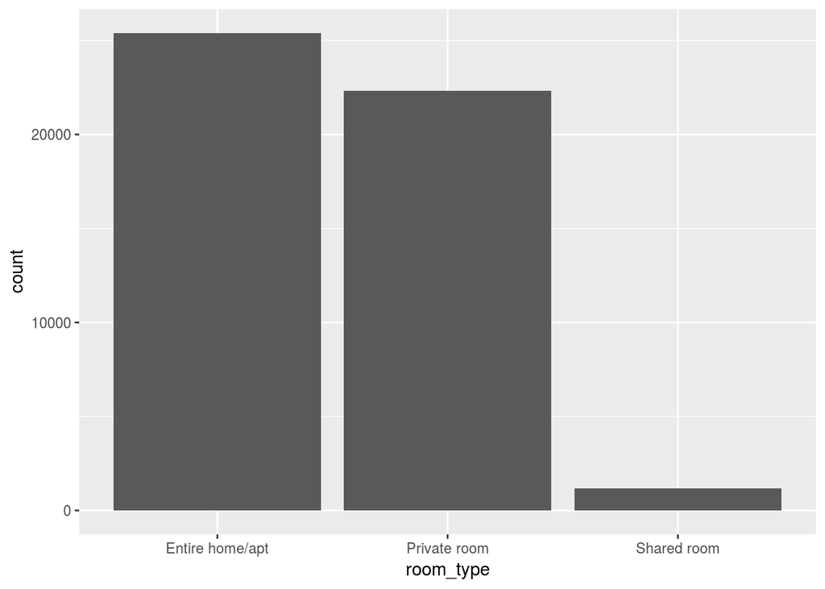

```r
ggplot(Listings, aes(room_type)) + geom_bar()
```

Here we can see that Entire home/apt and Private room are the most common listing.

Now I am going to plot the average price of listings based on what neighborhood group they are in.

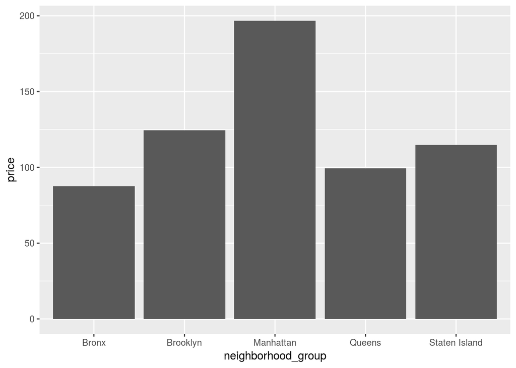

```r
ggplot(Listings, aes(neighborhood_group, price)) + stat_summary(fun.y = "mean", geom = "bar")
```

We can see that the average price for Manhattan is much more expensive than any other neighborhood. On the other end, we can see that the Bronx is the cheapest on average, but not by a lot.

## Research Questions

Some Research Questions that I have about this topic:

–What factors lead to having a positive review, such as pricing and location?  
–Can we determine if hosts with mulitple listings tend to buy in a similar area?  
–How do hosts determine what price they put their listing at?